# Gabarito de Correção: Tarefa de Funções e Tidy Evaluation

Computação em Estatística II

Autor

Prof. Donald M. Pianto

Data de Publicação

26 de setembro de 2025

## Introdução

Este documento apresenta a solução e a distribuição de pontuação para a “Tarefa: Criação de Funções com Tidy Evaluation”, com critérios ajustados para refletir a complexidade dos problemas em relação ao material de aula.

**Pontuação Total:** 10 pontos.

## Problema 1: Função para Gráfico de Dispersão Dinâmico (2.0 pontos)

### Solução

**Código**

```r
library(tidyverse)
library(palmerpenguins)
library(rlang)

plotar_dispersao <- function(df, var_x, var_y) {
  ggplot(df, aes(x = {{ var_x }}, y = {{ var_y }})) +
    geom_point(alpha = 0.8) +
    labs(
      title = paste("Gráfico de Dispersão de", rlang::as_name(rlang::enquo(var_y))),
      subtitle = paste("em função de", rlang::as_name(rlang::enquo(var_x))),
      x = rlang::as_name(rlang::enquo(var_x)),
      y = rlang::as_name(rlang::enquo(var_y))
    ) +
    theme_minimal()
}
```

### Testes da Função

**Código**

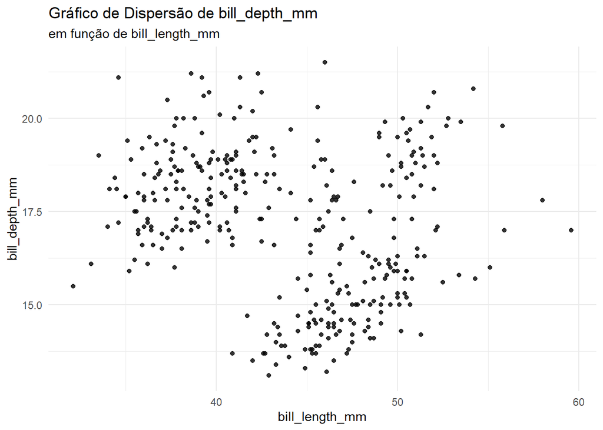

```r
# Teste 1
plotar_dispersao(penguins, bill_length_mm, bill_depth_mm)
```

**Código**

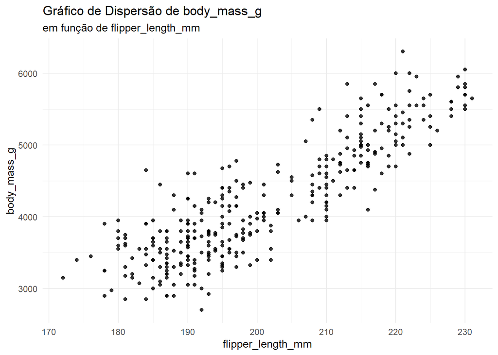

```r
# Teste 2
plotar_dispersao(penguins, flipper_length_mm, body_mass_g)
```

### Critérios de Pontuação (2.0 pontos)

- **[1.0 pt]** A função `plotar_dispersao` é definida corretamente com os três argumentos (`df`, `var_x`, `var_y`).
- **[1.0 pt]** Usa corretamente o operador `{ }` dentro de `aes()` para os argumentos `var_x` e `var_y`. A criação de títulos dinâmicos com `as_name(enquo(...))` é um bónus e não é necessária para a pontuação total deste item, mas demonstra um domínio avançado.

## Problema 2: Função de Sumarização por Grupo (2.5 pontos)

### Solução

A solução completa e robusta exige o uso de `across()` dentro de `group_by()` para lidar com um ou múltiplos argumentos de agrupamento.

**Código**

```r
sumarizar_por_grupo <- function(df, var_grupo, var_sumario) {
  df |>
    group_by(across({{ var_grupo }})) |>
    summarise(
      "media_{{var_sumario}}" := mean({{ var_sumario }}, na.rm = TRUE),
      "dp_{{var_sumario}}" := sd({{ var_sumario }}, na.rm = TRUE),
      n = n()
    )
}
```

### Testes da Função

**Código**

```r
# Teste 1
sumarizar_por_grupo(penguins, species, body_mass_g)
```

```
# A tibble: 3 × 4
  species   media_body_mass_g dp_body_mass_g     n
  <fct>                 <dbl>          <dbl> <int>
1 Adelie                3701.           459.   152
2 Chinstrap             3733.           384.    68
3 Gentoo                5076.           504.   124
```

**Código**

```r
# Teste 2
sumarizar_por_grupo(penguins, c(species, sex), bill_length_mm)
```

```
# A tibble: 8 × 5
# Groups:   species [3]
  species   sex    media_bill_length_mm dp_bill_length_mm     n
  <fct>     <fct>                 <dbl>             <dbl> <int>
1 Adelie    female                 37.3              2.03    73
2 Adelie    male                   40.4              2.28    73
3 Adelie    <NA>                   37.8              2.80     6
4 Chinstrap female                 46.6              3.11    34
5 Chinstrap male                   51.1              1.56    34
6 Gentoo    female                 45.6              2.05    58
7 Gentoo    male                   49.5              2.72    61
8 Gentoo    <NA>                   45.6              1.37     5
```

### Critérios de Pontuação (2.5 pontos)

- **[0.5 pts]** A função `sumarizar_por_grupo` é definida corretamente com os três argumentos e o nome correto.
- **[1.0 pt]** Usa corretamente o operador `:=` e a sintaxe de cola (`"prefixo_{{variavel}}"`) para criar nomes de colunas dinâmicos.
- **[1.0 pt]** Solução para o agrupamento:
  - **(1.0 pt - Completo)** A solução é robusta, usando `group_by(across({{ var_grupo }}))` para passar nos dois testes.
  - **(0.5 pts - Parcial)** A solução funciona apenas para uma única variável de agrupamento (ex: `group_by({{ var_grupo }})`), passando no primeiro teste mas falhando no segundo. Isso demonstra a compreensão do conceito básico de `{ }`.

## Problema 3: Função para Contagem Ponderada (2.5 pontos)

### Solução

A tarefa especifica que ambas as variáveis são fornecidas como **strings**, exigindo o uso do pronome `.data` com a indexação `[[...]]`.

**Código**

```r
contagem_ponderada <- function(df, var_categorica, var_peso) {
  df |>
    group_by(.data[[var_categorica]]) |>
    summarise(
      n = sum(.data[[var_peso]], na.rm = TRUE)
    )
}
```

### Testes da Função

**Código**

```r
# Teste 1
contagem_ponderada(penguins, "island", "body_mass_g")
```

```
# A tibble: 3 × 2
  island         n
  <fct>      <int>
1 Biscoe    787575
2 Dream     460400
3 Torgersen 189025
```

**Código**

```r
# Teste 2
contagem_ponderada(penguins, "species", "flipper_length_mm")
```

```
# A tibble: 3 × 2
  species       n
  <fct>     <int>
1 Adelie    28683
2 Chinstrap 13316
3 Gentoo    26714
```

### Critérios de Pontuação (2.5 pontos)

- **[0.5 pts]** A função `contagem_ponderada` é definida corretamente com os três argumentos.
- **[2.0 pts]** Uso correto do pronome `.data`:
  - **(2.0 pts - Completo)** Usa corretamente `.data[[...]]` para **ambos** os argumentos `var_categorica` e `var_peso`.
  - **(1.0 pt - Parcial)** Usa corretamente `.data[[...]]` para apenas um dos dois argumentos, mas tenta uma abordagem plausível (mesmo que incorreta, como `{...}`) para o outro.
  - **(0.5 pts - Tentativa)** Tenta uma abordagem de Tidy Evaluation para lidar com as strings (ex: `group_by(!!var_categorica)`), demonstrando que entendeu o problema, mas não usou a sintaxe correta do `.data`.

## Problema 4: Função de Plotagem Avançada (Integrador) (3.0 pontos)

### Solução

**Código**

```r
plotar_avancado <- function(df,
                            var_x,
                            var_y,
                            var_facet = NULL,
                            adicionar_linha_tendencia = TRUE,
                            ...) {

  # --- Validação de Entradas ---
  dados_x <- df |> pull({{var_x}})
  dados_y <- df |> pull({{var_y}})

  if (!is.numeric(dados_x) || !is.numeric(dados_y)) {
    stop("As variáveis 'var_x' e 'var_y' devem ser numéricas.")
  }

  # --- Lógica do Gráfico ---
  p <- ggplot(df, aes(x = {{ var_x }}, y = {{ var_y }})) +
    geom_point(alpha = 0.7)

  # Adicionar linha de tendência condicionalmente
  if (adicionar_linha_tendencia) {
    p <- p + geom_smooth(method = "lm", se = FALSE, color = "blue")
  }

  # Adicionar facetas condicionalmente
  if (!rlang::quo_is_null(rlang::enquo(var_facet))) {
    p <- p + facet_wrap(vars({{ var_facet }}))
  }

  # Adicionar títulos (passados via ...) e tema
  p <- p +
    labs(...) +
    theme_minimal()

  return(p)
}
```

### Testes da Função

**Código**

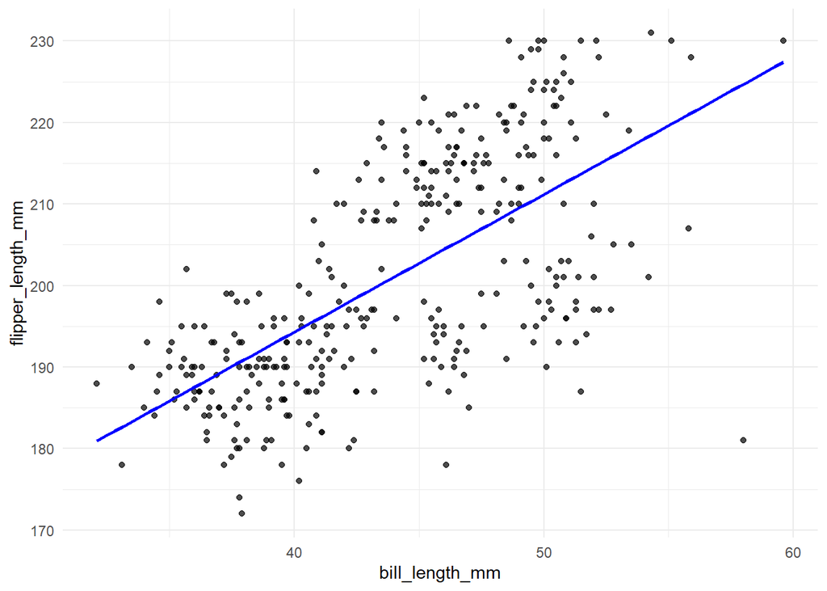

```r
# Testes a, b, c, d
plotar_avancado(penguins, bill_length_mm, flipper_length_mm)
```

**Código**

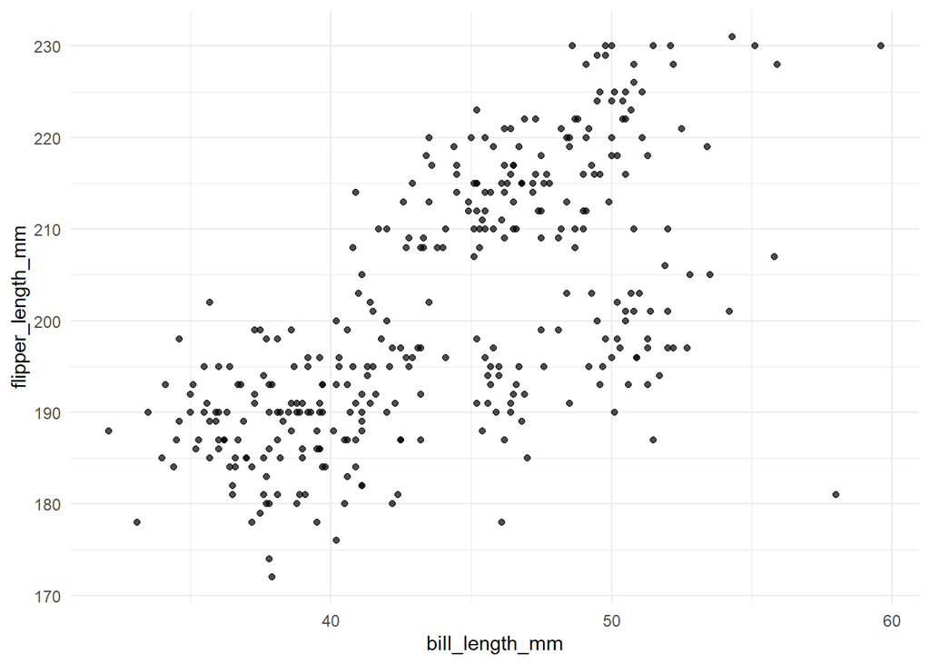

```r
plotar_avancado(penguins, bill_length_mm, flipper_length_mm, adicionar_linha_tendencia = FALSE)
```

**Código**

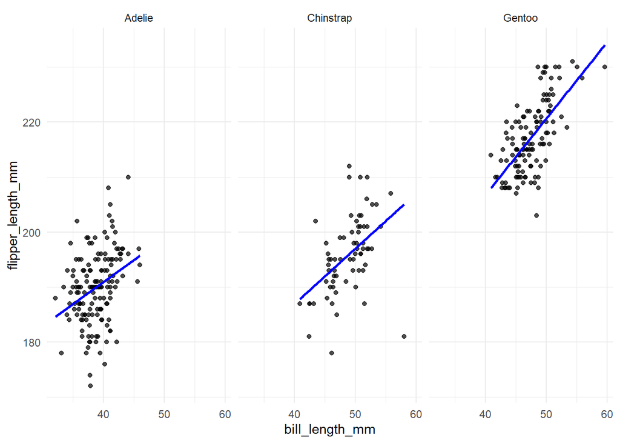

```r
plotar_avancado(penguins, bill_length_mm, flipper_length_mm, var_facet = species)
```

**Código**

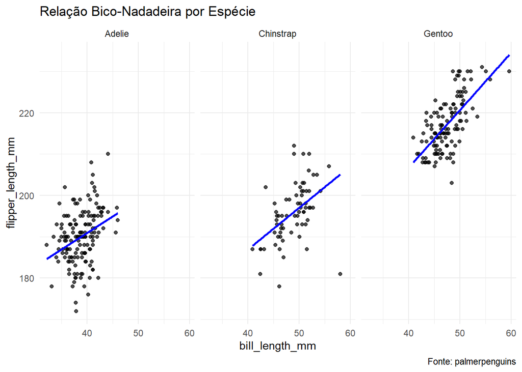

```r
plotar_avancado(
  df = penguins, var_x = bill_length_mm, var_y = flipper_length_mm,
  var_facet = species, adicionar_linha_tendencia = TRUE,
  title = "Relação Bico-Nadadeira por Espécie", caption = "Fonte: palmerpenguins"
)
```

**Código**

```r
# Teste e
try(plotar_avancado(penguins, bill_length_mm, island), silent = FALSE)
```

```
Error in plotar_avancado(penguins, bill_length_mm, island) :
  As variáveis 'var_x' e 'var_y' devem ser numéricas.
```

### Critérios de Pontuação (3.0 pontos)

- **[1.0 pt]** Definição da Função e Lógica Principal: Define a função com a assinatura correta (argumentos, valores padrão, `...`). Usa `{ }` corretamente para `var_x`, `var_y`, e `var_facet`. Passa `...` para `labs()`.
- **[1.0 pt]** Lógica Condicional: Implementa corretamente as duas estruturas `if`: uma para a linha de tendência e outra para as facetas. A verificação para as facetas `(!rlang::quo_is_null(enquo(var_facet)))` é avançada; qualquer abordagem que verifique se o argumento `var_facet` foi fornecido (mesmo que mais simples, como `!is.null(enexpr(var_facet)))` deve receber crédito total.
- **[1.0 pt]** Validação de Entradas:
  - **(1.0 pt - Completo)** Implementa uma validação funcional que verifica se as colunas são numéricas e usa `stop()`.
  - **(0.5 pts - Parcial)** O aluno tenta fazer a validação e demonstra a lógica correta (ex: `if(!is.numeric(...)))`, mas a implementação falha devido às complexidades da Tidy Evaluation (ex: `if(!is.numeric(var_x)))`. Isso mostra que o aluno entendeu a necessidade da validação.